# Economía Matemática: Tarea 1

# Primera parte: Conjuntos

1. Sea $\mathbb{N}$ el conjunto de los números naturales. Describa por enumeración -es decir, liste los elementos de:
   $$A:=\left \{x\in
   \mathbb{N}:40<x^{2}<80\right \}$$
   .

Solución: $A=\left \{x\in \mathbb{N}:40<x^{2}<80\right \} = \left \{ 7,8 \right \}$

2. Sean A y B subconjuntos de $\mathbb{R}^{2}$ definidos como sigue:
   $$A:=\left \{ (x,y):xy<0 \right \}
   \hspace{1cm} B:=\left \{ (x,y):y^{2} > 4 \right \}$$
   .
   Represente mediante un gráfico los siguientes conjuntos: (a) $A\cup B$. (b) $A\cap B$. (c) $A^{c}$. (d) $B^{c}$. (Observación: Si alguna de las propiedades que definen los conjuntos anteriores no incluye alguna coordenada, esta última es libre de tomar cualquier valor.)

Solución:

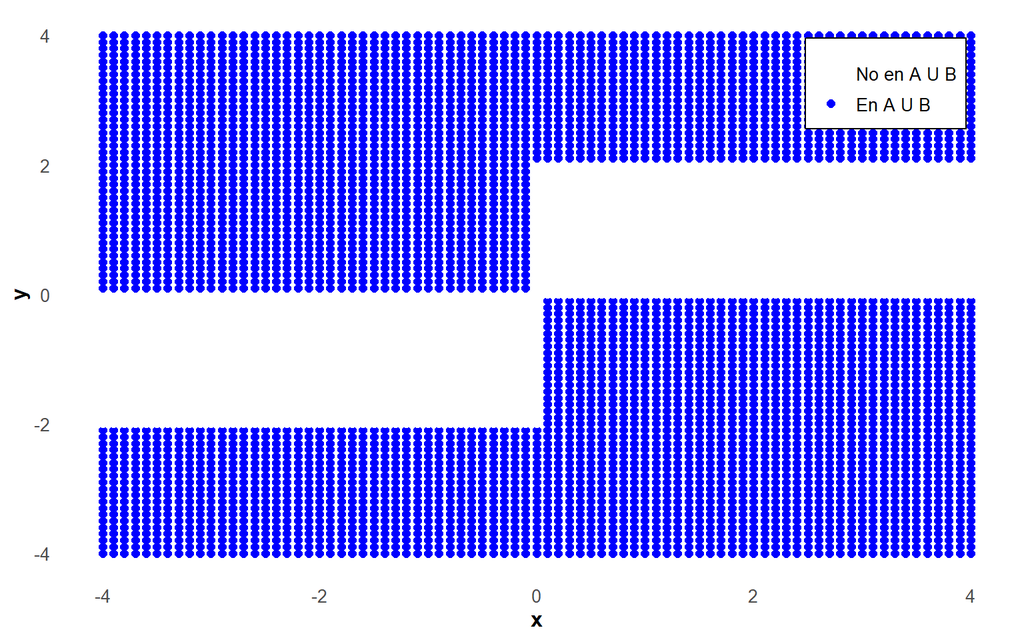

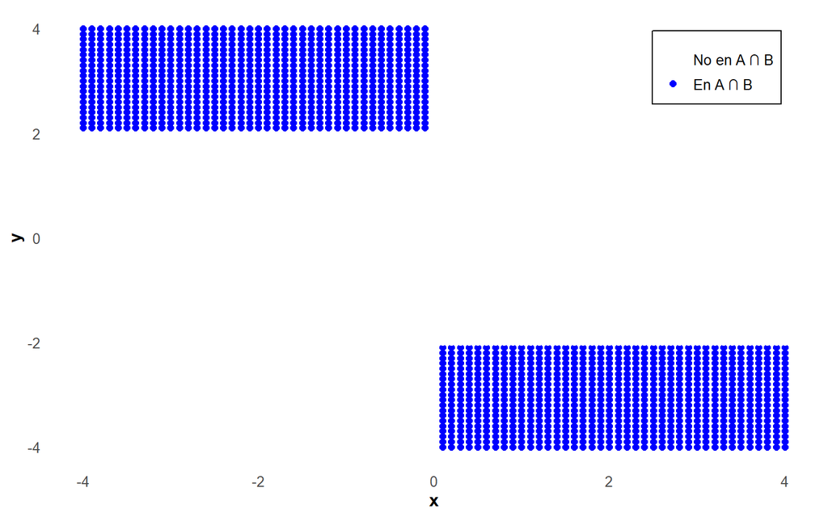

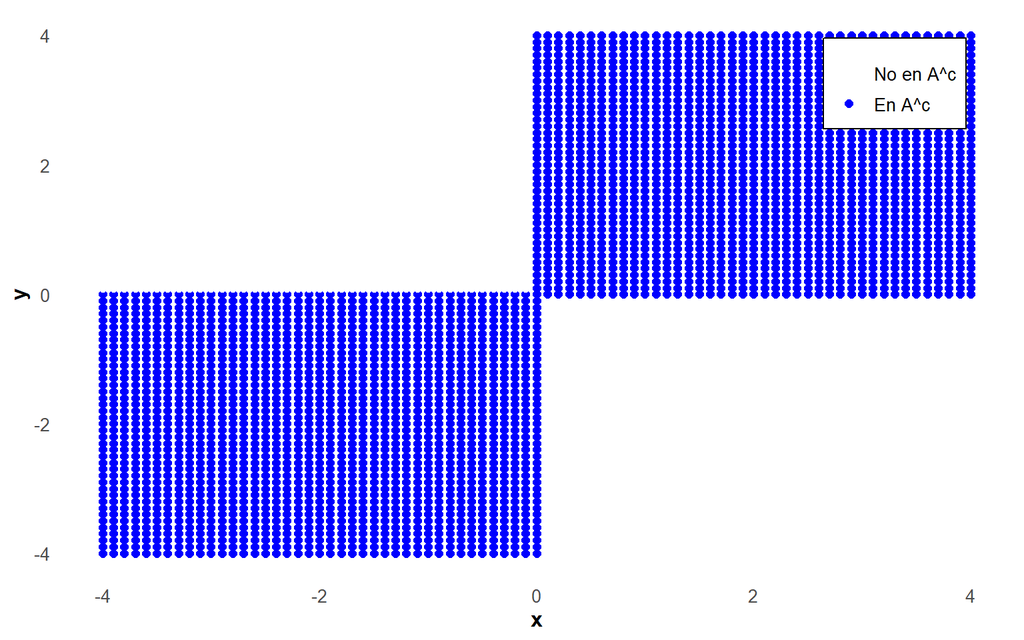

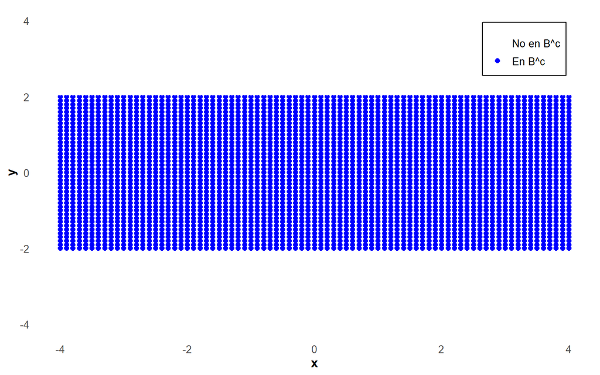

3. Encuentre todos los subconjuntos de $A:=\left \{ 1,b,c \right \}$.

Solución:

Subconjunto vacío: $\emptyset$.  
Subconjuntos con un solo elemento:  
$=\left \{ 1\right \}$  
$=\left \{ b\right \}$  
$=\left \{ c\right \}$  
Subconjuntos con dos elementos:  
$=\left \{ 1,b\right \}$  
$=\left \{ 1,c\right \}$  
$=\left \{ b,c\right \}$  
Subconjunto con todos los elementos:  
$=\left \{ 1,b,c\right \}$

# Segunda parte: Funciones

1. Considere las siguientes funciones cuyo dominio es el conjunto de los números reales: (a) $y=3x-2$, (b) $y=-2x$, (c) $y=x^{2}+1$, (d) $y=x^{3}+x$, (e) $y=x^{3}-x$.
1. Obtenga el gráfico de las funciones anteriores. (Observación: si lo desea puede usar google).

Solución:

$$y=3x-2$$

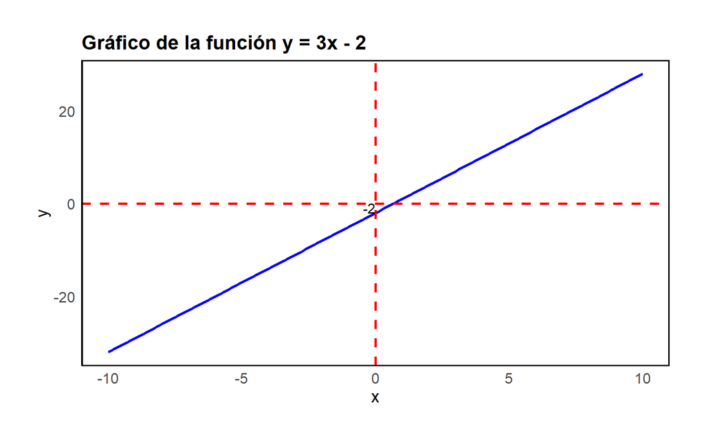

$$y=-2x$$

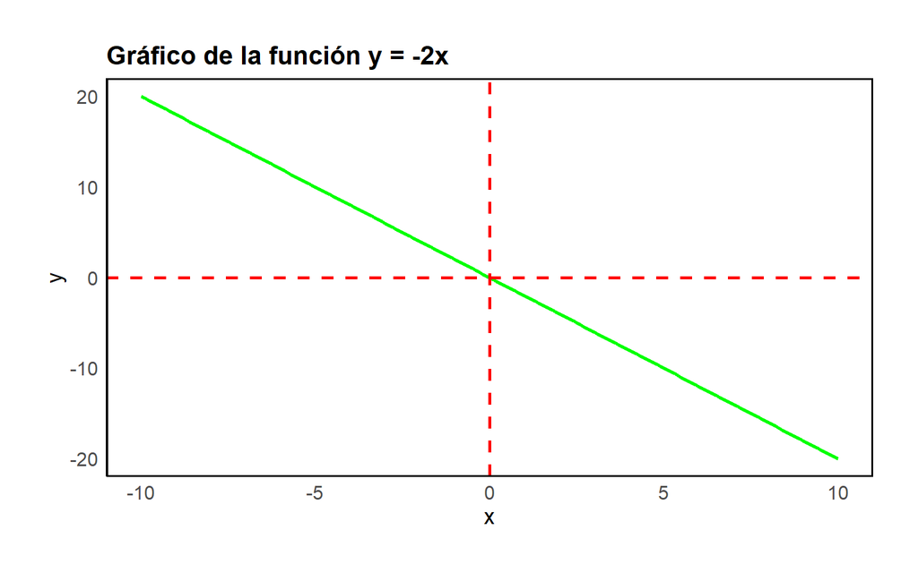

$$y=x^{2}+1$$

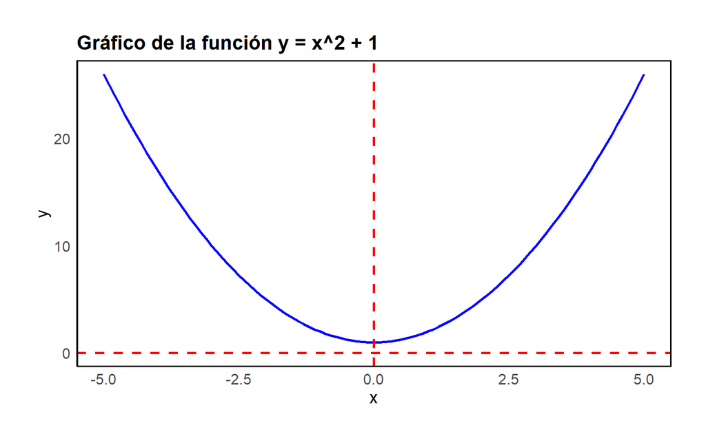

$$y=x^{3}+x$$

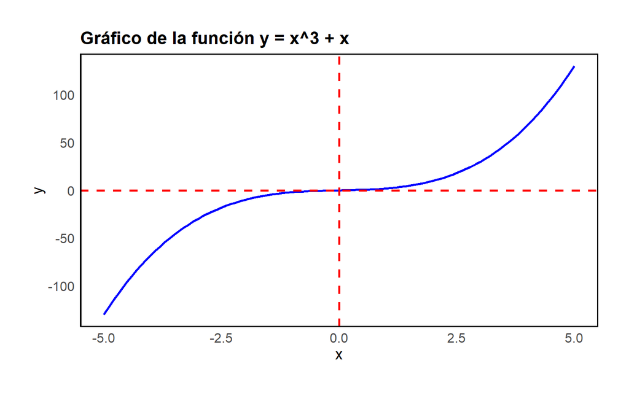

$$y=x^{3}-x$$

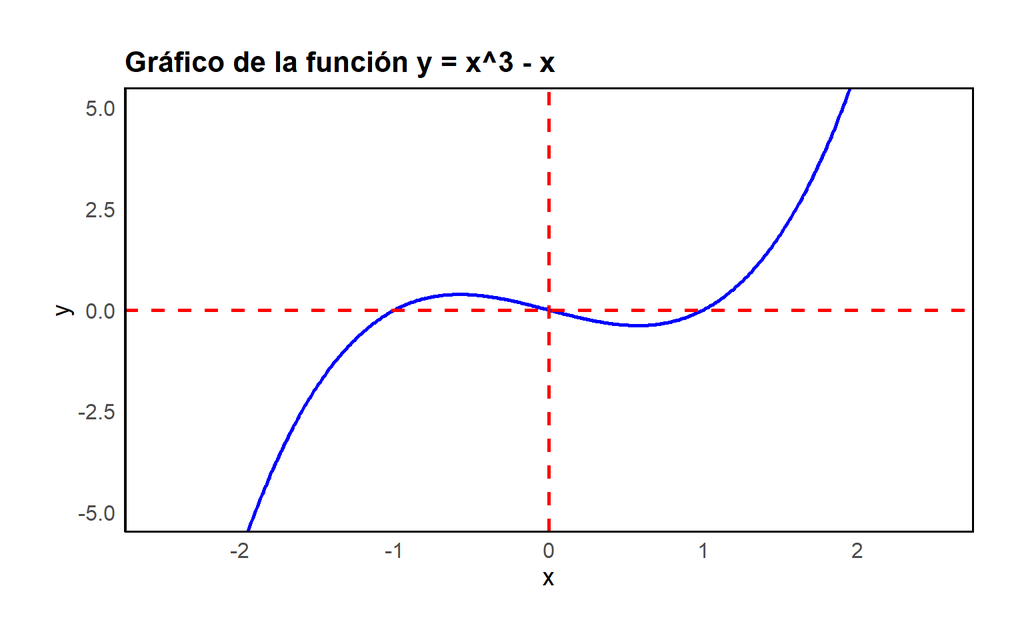

2. Encuentre los subconjuntos del dominio para los cuales las funciones anteriores son crecientes. Encuentre también los subconjuntos del dominio para los cuales las funciones anteriores son decrecientes.

Solución:

$y=3x-2$ =
$$\frac{\partial y}{\partial x}=3$$

Como la derivada es una constante positiva, esta función siempre sera creciente.

- La función es creciente en $(-\infty,\infty).$
- La función es decreciente en ningun subconjunto: $\emptyset$.

$y=-2x$ =
$$\frac{\partial y}{\partial x}=-2$$

Como la derivada es una constante negativa, esta función siempre sera decreciente.

- La función es creciente en ningun subconjunto: $\emptyset$.
- La función es decreciente en $(-\infty,\infty).$

$y=x^{2}+1$ =
$$\frac{\partial y}{\partial x}=2x$$

Aqui, la función sera decreciente o creciente dependiendo del valor que tome x.

- La función es creciente en el intervalo $(0,\infty).$
- La función es decreciente en el intervalo $(-\infty,0).$

$y=x^{3}+x$ =
$$\frac{\partial y}{\partial
x}=3x^{2}+1$$

Esta función siempre sera creciente debido a que no importa que valor tome x la función siempre sera positiva.

- La función es creciente en el intervalo $(-\infty, \infty).$
- La función es decreciente en el intervalo $(\emptyset).$

$y=x^{3}-x$ =
$$\frac{\partial y}{\partial
x}=3x^{2}-1$$

- La función es creciente en el intervalo $(-\infty,-\frac{1}{\sqrt{3}})\cup (\frac{1}{\sqrt{3}},\infty)$
- La función es decreciente en el intervalo $(-\frac{1}{\sqrt{3}},\frac{1}{\sqrt{3}})$
3. Considere la función $F:\mathbb{R}\rightarrow \mathbb{R}$ defininida como:
   $$F(x)=2x^{2}+1$$
   Encuentre el conjunto imagen de F:
   $$F(\mathbb{R}):=\left \{ y\in \mathbb{R}:y=F(x)
   \hspace{0,1cm} para \hspace{0,1cm} algun \hspace{0,1cm} x\in
   \mathbb{R} \right \}$$

Solución:
$$F(\mathbb{R})=\left \{ y\in
\mathbb{R}:y\geq 1 \right \}$$

# Tercera parte: Conjuntos Convexos

1. Sean S y T conjuntos convexos. Demuestre que los siguientes conjuntos son convexos.
1. $-S:=\left \{ u:u=-s,s\in S \right \}$
2. $S-T:=\left \{ v:v=s-t,s\in S,t\in T \right \}$

Solución:

Sea $u_1$ un punto en $-S$. Esto significa que existe un punto $s_1$ en $S$ tal que $u_1 = -s_1$. (Notación: $u_1 \in -S \Rightarrow u_1 = -s_1$).

Sea $u_2$ otro punto en $-S$. Esto significa que existe un punto $s_2$ en $S$ tal que $u_2 = -s_2$. (Notación: $u_2 \in -S \Rightarrow u_2 = -s_2$).

Ahora, queremos demostrar que la línea recta que une $u_1$ y $u_2$ está completamente dentro de $-S$. Para ello, definimos la línea recta que une los puntos $u_1$ y $u_2$ como:

$$L=\left \{ u:u=\lambda u_{1}+(1-\lambda
)u_{2}, 0\leq \lambda \leq 1 \right \}$$

Debemos mostrar que: cualquier punto $u$ en la línea recta $L$ también está en $-S$. Esto significa que debemos encontrar un punto $s$ en $S$ tal que $u = -s$.

Sustituyendo la expresión de $L$ en la ecuación $u = -s$ y simplificando, obtenemos: $\lambda u_{1}+(1-\lambda)u_{2}=-s$.

Ahora, sustituyendo $u_1 = -s_1$ y $u_2 = -s_2$ en la ecuación anterior: $\lambda (-s_{1})+(1-\lambda)(-s_{2})=-s$

Simplificando aún más: $-(\lambda s_{1}+(1-\lambda)s_{2})=-s$

Finalmente, multiplicando toda la ecuación por $-1$, obtenemos: $\lambda s_{1}+(1-\lambda)s_{2}=s$

Ahora notamos que $s$, el punto en $S$ que buscábamos, está en la línea recta $L$ que une $u_1$ y $u_2$.

Como encontramos que para cualquier punto $u$ en la línea recta $L$ siempre podemos hallar un punto $s$ en $S$ tal que $u = -s$, esto implica que la línea recta $L$ está completamente dentro de $-S$.

Dado que hemos demostrado que cualquier línea recta que une puntos dentro de $-S$ también está dentro de $-S$, podemos concluir que $-S$ es un conjunto convexo.

Para este inciso el proceso es distinto pero la lógica es la misma. Por tanto;

Dado que $S$ y $T$ son conjuntos convexos, tomemos dos puntos $v_1$ y $v_2$ en $S-T$. Esto significa que existen puntos $s_1 \in S$ y $t_1 \in T$ tales que $v_1 = s_1 - t_1$ y también existen puntos $s_2 \in S$ y $t_2 \in T$ tales que $v_2 = s_2 - t_2$.

Ahora, consideremos la línea recta que une los puntos $v_1$ y $v_2$, que denotaremos como $L = {v: v = \lambda v_1 + (1-\lambda) v_2, 0 \leq \lambda \leq 1}$.

Nuestra tarea es demostrar que cualquier punto $v$ en la línea recta $L$ también está en $S-T$. Esto significa que debemos encontrar puntos $s \in S$ y $t \in T$ tal que $v = s - t$.

Sustituyendo la expresión de $L$ en la ecuación $v = s - t$ y simplificando, obtenemos: $\lambda v_{1}+(1-\lambda)v_{2}=s-t$

Sustituyendo $v_1 = s_1 - t_1$ y $v_2 = s_2 - t_2$ en la ecuación anterior, tenemos: $\lambda (s_{1}-t_{1})+(1-\lambda)(s_{2}-t_{2})=s-t$

Simplificando, obtenemos: $\lambda s_{1}+(1-\lambda)s_{2}-(\lambda t_{1}+(1-\lambda)t_{2})=s-t$

Definamos $s = \lambda s_1 + (1-\lambda) s_2$ y $t = \lambda t_1 + (1-\lambda) t_2$. Ahora, notamos que $s \in S$ y $t \in T$. Entonces, la ecuación se convierte en: $s-t=s-t$

Lo cual es verdadero para cualquier punto $v$ en la línea recta $L$. Esto implica que la línea recta $L$ está completamente dentro de $S-T$.

Dado que hemos demostrado que cualquier línea recta que une puntos dentro de $S-T$ también está dentro de $S-T$, podemos concluir que $S-T$ es un conjunto convexo.